# AKFIN_WebService

Jordan Watson

1/31/2021

```r
library(httr)
library(tidyverse)
library(lubridate)
library(sp)
library(rgdal)
library(ggrepel)
```

Satellite data provide information across broad spatial and temporal extents. These data are often valuable for linkage with biological or fishery data for connection to stock assessments or other fishery evaluations. In recent years, access to these satellite data has expanded dramatically, enabling users to easily query and download a suite of environmental datasets in gridded forms through user-friendly interfaces like ERDAPP data servers (https://coastwatch.pfeg.noaa.gov/erddap/index.html). One limitation to the basic ERDDAP functionality is that users must specify spatial extents of their data downloads in rectangular polygons. Supplementary tools have been created (e.g., the R package “rerddapXtracto”,https://cran.r-project.org/web/packages/rerddapXtracto/) that include workarounds to this limitation but some bottlenecks still remain. For example, many users may be interested simply in a time series of daily, weekly, or monthly average sea surface temperatures (SST) across their spatial extent of interest. To extract this information using the rerddapXtracto or the ERDDAP interfaces, a user must first download all of the individual SST temperature values across their spatial grid before they can then calculate the single average SST value of interest. Such an operation can be time-consuming because the Alaska SST grid, for example, contains more than 200,000 SST records for each day. This time consuming operation may also be inefficient if the end user simply wants to aggregate the data across large spatial areas.

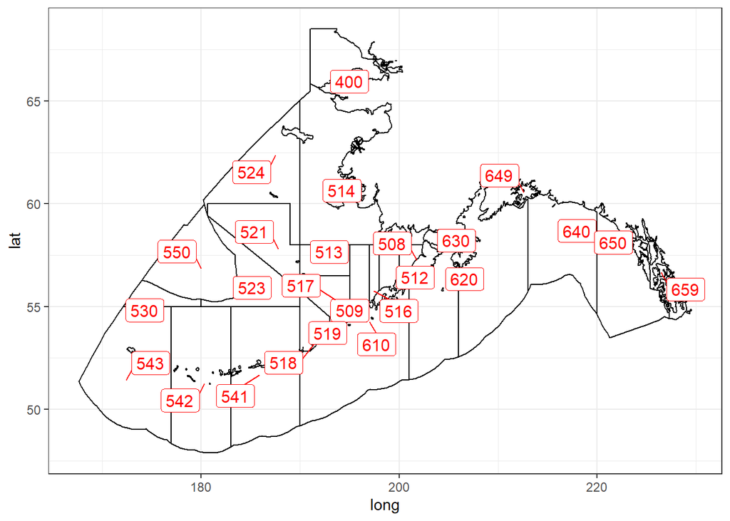

Map of the NMFS management areas for Alaska, illustrating each of the NMFS spatial strata for which SST data are averaged daily.

## Web Service

AKFIN has created a set of web services or web APIs for accessing the pre-summarized / spatially aggregated data for a set of different ecosystem and management areas. AKFIN downloads the CRW satellite SST dataset daily for the spatial extent of Alaska. Files are downloaded daily as two separate netCDF files - one for positive and one for negative longitudes. The daily data are then clipped by merging them with a spatial lookup table that encompasses the exclusive economic zone (EEZ) of Alaska. The data are merged into a single daily gridded dataset that includes 212,813 temperature records for each day. We have identified several spatial strata that are of particular interest from either the ecosystem or management perspective. These fields in the data are referred to as *Ecosystem_sub* or *nmfsarea*. The goal of the AKFIN web service is to streamline access to the average daily temperatures within each of the relevant strata.

```r
lkp <- readRDS("Data/crwsst_spatial_lookup_table.RDS")
head(lkp)
```

```
##     id statefed stat_area depth longitude latitude nmfsarea bsierp_id
## 1 1742      FED    686800   -54  -168.975   68.475      400        NA
## 2 1743      FED    686800   -54  -168.925   68.475      400        NA
## 3 1744      FED    686800   -54  -168.875   68.475      400        NA
## 4 1745      FED    686800   -53  -168.825   68.475      400        NA
## 5 1746      FED    686800   -53  -168.775   68.475      400        NA
## 6 1747      FED    686800   -51  -168.725   68.475      400        NA
##   bsierp_name Ecosystem Ecosystem_sub
## 1        <NA>      <NA>          <NA>
## 2        <NA>      <NA>          <NA>
## 3        <NA>      <NA>          <NA>
## 4        <NA>      <NA>          <NA>
## 5        <NA>      <NA>          <NA>
## 6        <NA>      <NA>          <NA>
```

The **Ecosystem_sub** field in our lookup table contains all of the different ecosystem regions that can be queried from the data. Note that not every point in our dataset falls within an ecosystem region and thus NAs do exist in the data.

For subregions in the Bering Sea and Gulf of Alaska, the query filters only data where water depth is between 10 and 200m. For the Aleutian Islands, a depth filter does not exist. Analysts that are interested in obtaining data that have not been filtered can contact the authors of this report.

```r
unique(lkp$Ecosystem_sub)
```

```
## [1] NA                        "Northern Bering Sea"
## [3] "Western Gulf of Alaska"  "Eastern Gulf of Alaska"
## [5] "Southeastern Bering Sea" "Eastern Aleutians"
## [7] "Central Aleutians"       "Western Aleutians"
```

The web service simply enables us to query data using a URL, where the URL itself contains information for querying data from the server. In the first example we will query the URL, “https://apex.psmfc.org/akfin/data_marts/akmp/ecosystem_sub_crw_avg_sst?ecosystem_sub=Southeastern%20Bering%20Sea”, where “ecosystem_sub_crw_avg_sst?” is the name of the dataset we are querying. This is the daily CRW SST dataset, which has been averaged by the field ecosystem_sub. As noted previously, there are seven *ecosystem_sub* options. To query the data for the “Southeastern Bering Sea”, for example, add “ecosystem_sub=Southeastern%20Bering%20Sea”, where a “?” separates the dataset name from the query criteria and spaces are filled by “%20”. The default behavior is to pull a single record, the most recent in the data set. The web service encodes the data as “json” so R must be told how to decode the data using the type = “application/json” argument. The default behavior returns a list.

```r
httr::content(httr::GET('https://apex.psmfc.org/akfin/data_marts/akmp/ecosystem_sub_crw_avg_sst?ecosystem_sub=Southeastern%20Bering%20Sea'), type = "application/json")
```

```
## [[1]]
## [[1]]$MEANSST
## [1] 1.48
##
## [[1]]$ECOSYSTEM_SUB
## [1] "Southeastern Bering Sea"
##
## [[1]]$READ_DATE
## [1] "2021-02-18T12:00:00Z"
##
## [[1]]$YEAR
## [1] "2021"
##
## [[1]]$JULIAN
## [1] "049"
```

Instead of a list, these data can easily be converted to a data frame (tibble). Note that we use “bind_rows” here instead of data.frame. This will have the same effect as data.frame but means we will not have to change the code when more dates are added in subsequent examples.

```r
httr::content(httr::GET('https://apex.psmfc.org/akfin/data_marts/akmp/ecosystem_sub_crw_avg_sst?ecosystem_sub=Southeastern%20Bering%20Sea'), type = "application/json") %>%
  bind_rows
```

```
## # A tibble: 1 x 5
##   MEANSST ECOSYSTEM_SUB           READ_DATE            YEAR  JULIAN
##     <dbl> <chr>                   <chr>                <chr> <chr>
## 1    1.48 Southeastern Bering Sea 2021-02-18T12:00:00Z 2021  049
```

To query multiple values of a parameter, separate the values by a comma. For example, to query the Southeastern and the Northern Bering Sea data:

```r
httr::content(httr::GET('https://apex.psmfc.org/akfin/data_marts/akmp/ecosystem_sub_crw_avg_sst?ecosystem_sub=Southeastern%20Bering%20Sea,Northern%20Bering%20Sea'), type = "application/json") %>%
  bind_rows
```

```
## # A tibble: 2 x 5
##   MEANSST ECOSYSTEM_SUB           READ_DATE            YEAR  JULIAN
##     <dbl> <chr>                   <chr>                <chr> <chr>
## 1   -1.48 Northern Bering Sea     2021-02-18T12:00:00Z 2021  049
## 2    1.48 Southeastern Bering Sea 2021-02-18T12:00:00Z 2021  049
```

```r
httr::content(httr::GET('https://apex.psmfc.org/akfin/data_marts/akmp/ecosystem_sub_crw_avg_sst?ecosystem_sub=Central%20Aleutians,Eastern%20Aleutians&read_date=20100522&days_back=2'), type = "application/json") %>%
  bind_rows
```

```
## # A tibble: 6 x 5
##   MEANSST ECOSYSTEM_SUB     READ_DATE            YEAR  JULIAN
##     <dbl> <chr>             <chr>                <chr> <chr>
## 1    4    Central Aleutians 2010-05-19T12:00:00Z 2010  139
## 2    4.35 Eastern Aleutians 2010-05-19T12:00:00Z 2010  139
## 3    4.06 Central Aleutians 2010-05-20T12:00:00Z 2010  140
## 4    4.23 Eastern Aleutians 2010-05-20T12:00:00Z 2010  140
## 5    4.18 Central Aleutians 2010-05-21T12:00:00Z 2010  141
## 6    4.45 Eastern Aleutians 2010-05-21T12:00:00Z 2010  141
```

By omitting the specification of a particular date, the query will count back from the most recent date.

```r
httr::content(httr::GET('https://apex.psmfc.org/akfin/data_marts/akmp/ecosystem_sub_crw_avg_sst?ecosystem_sub=Central%20Aleutians,Eastern%20Aleutians&days_back=2'), type = "application/json") %>%
  bind_rows
```

```
## # A tibble: 6 x 5
##   MEANSST ECOSYSTEM_SUB     READ_DATE            YEAR  JULIAN
##     <dbl> <chr>             <chr>                <chr> <chr>
## 1    3.35 Central Aleutians 2021-02-16T12:00:00Z 2021  047
## 2    3.65 Eastern Aleutians 2021-02-16T12:00:00Z 2021  047
## 3    3.39 Central Aleutians 2021-02-17T12:00:00Z 2021  048
## 4    3.69 Eastern Aleutians 2021-02-17T12:00:00Z 2021  048
## 5    3.51 Central Aleutians 2021-02-18T12:00:00Z 2021  049
## 6    3.75 Eastern Aleutians 2021-02-18T12:00:00Z 2021  049
```

You can also specify a custom date period. Most users will want to query the entire duration of the time series, which for the CRW SST dataset begins on 1985-04-01. This start may soon be revised forward to 1985-01-01. To query a specific range, specify the “start_date” and “end_date”.

```r
httr::content(httr::GET('https://apex.psmfc.org/akfin/data_marts/akmp/ecosystem_sub_crw_avg_sst?ecosystem_sub=Eastern%20Gulf%20of%20Alaska&start_date=19850401&end_date=19850404'), type = "application/json") %>%
  bind_rows
```

[output not shown]

Note that simply specifying a start_date will not automatically query the duration of the time series. The below query returns zero rows.

```r
httr::content(httr::GET('https://apex.psmfc.org/akfin/data_marts/akmp/ecosystem_sub_crw_avg_sst?ecosystem_sub=Eastern%20Gulf%20of%20Alaska&start_date=19850401'), type = "application/json") %>%
  bind_rows
```

```
## data frame with 0 columns and 0 rows
```

However, if you do not know the most recent date of the time series, you can choose an end date some time far in the future and it will query all of the data that exist without an error.

```r
data <- httr::content(httr::GET('https://apex.psmfc.org/akfin/data_marts/akmp/ecosystem_sub_crw_avg_sst?ecosystem_sub=Eastern%20Gulf%20of%20Alaska&start_date=19850401&end_date=20220101'), type = "application/json") %>%
  bind_rows

head(data)
```

```
## # A tibble: 6 x 5
##   MEANSST ECOSYSTEM_SUB          READ_DATE            YEAR  JULIAN
##     <dbl> <chr>                  <chr>                <chr> <chr>
## 1    4.86 Eastern Gulf of Alaska 1985-04-01T12:00:00Z 1985  091
## 2    4.71 Eastern Gulf of Alaska 1985-04-02T12:00:00Z 1985  092
## 3    4.74 Eastern Gulf of Alaska 1985-04-03T12:00:00Z 1985  093
## 4    4.81 Eastern Gulf of Alaska 1985-04-04T12:00:00Z 1985  094
## 5    4.86 Eastern Gulf of Alaska 1985-04-05T12:00:00Z 1985  095
## 6    4.99 Eastern Gulf of Alaska 1985-04-06T12:00:00Z 1985  096
```

We can quickly see that the above query yielded more than 13,000 rows of data (i.e., daily data from 1985-04-01 to present).

```r
dim(data)
```

```
## [1] 13104     5
```

Putting the pieces all together, the data can be queried directly from AKFIN and saved, manipulated, or visualized directly. Here we query the full time series for the Eastern Gulf of Alaska and for the Eastern Aleutian Islands

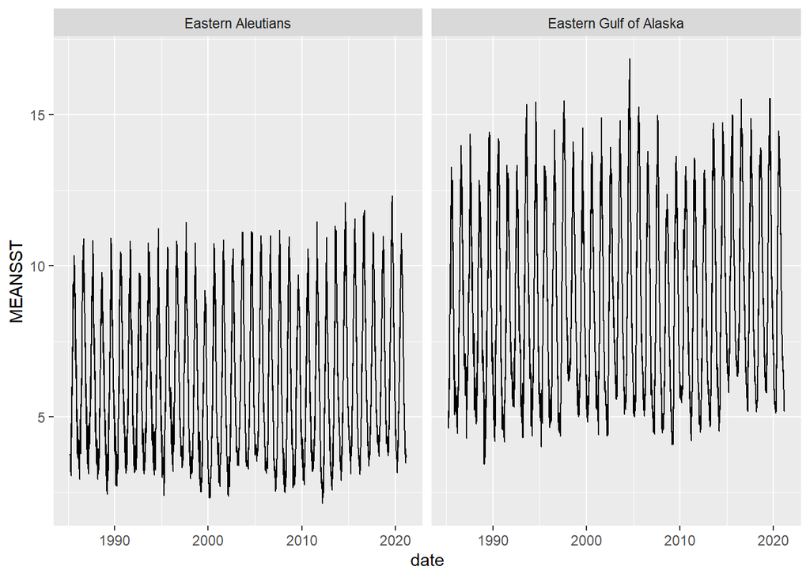

```r
httr::content(httr::GET('https://apex.psmfc.org/akfin/data_marts/akmp/ecosystem_sub_crw_avg_sst?ecosystem_sub=Eastern%20Gulf%20of%20Alaska,Eastern%20Aleutians&start_date=19850401&end_date=20220101'), type = "application/json") %>%
  bind_rows %>%
  mutate(date=as_date(READ_DATE)) %>%
  ggplot(aes(date,MEANSST)) +
  geom_line() +
  facet_wrap(~ECOSYSTEM_SUB)
```

Or for the Eastern Gulf of Alaska for a single year.

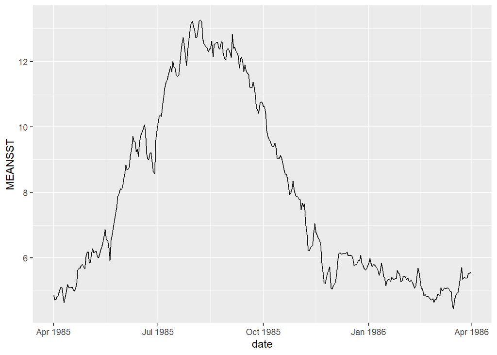

```r
httr::content(httr::GET('https://apex.psmfc.org/akfin/data_marts/akmp/ecosystem_sub_crw_avg_sst?ecosystem_sub=Eastern%20Gulf%20of%20Alaska&start_date=19850401&end_date=19860401'), type = "application/json") %>%
  bind_rows %>%
  mutate(date=as_date(READ_DATE)) %>%
  ggplot(aes(date,MEANSST)) +
  geom_line()
```

An alternative query method is to pull data by NMFS area. These areas are particuarly relevant to stock assessment scientists. Currently, NMFS areas can be queried individually (daily means calculated for each NMFS area). If individual users / assessment authors would prefer means calculated using the raw data for multiple areas pooled, they can contact the authors and we can arrange for custom aggregates.

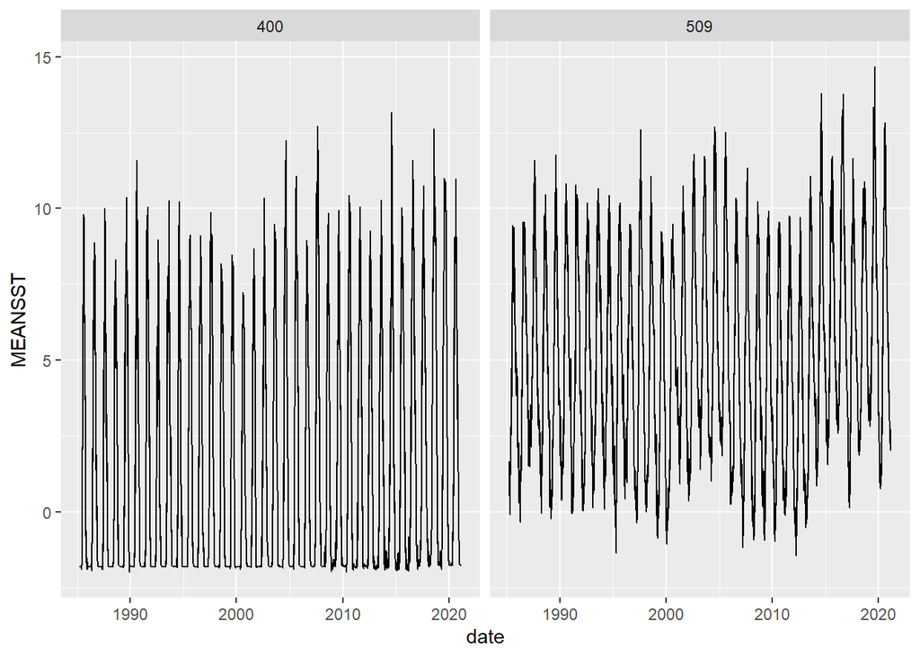

```r
httr::content(httr::GET('https://apex.psmfc.org/akfin/data_marts/akmp/nmfs_area_crw_avg_sst?nmfs_area=400,509&start_date=19850401&end_date=20220101'), type = "application/json") %>%
  bind_rows %>%
  mutate(date=as_date(READ_DATE)) %>%
  ggplot(aes(date,MEANSST)) +
  geom_line() +
  facet_wrap(~NMFSAREA)
```

One could alternatively query and summarize data by month (week, year, etc) by simply grouping and summarizing the data in-line.

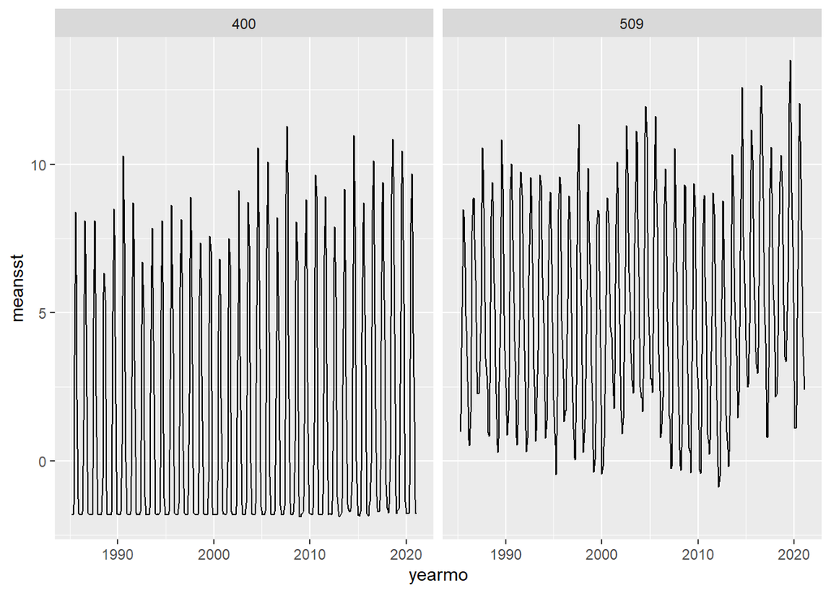

```r
httr::content(httr::GET('https://apex.psmfc.org/akfin/data_marts/akmp/nmfs_area_crw_avg_sst?nmfs_area=400,509&start_date=19850401&end_date=20220101'), type = "application/json") %>%
  bind_rows %>%
  mutate(date=as_date(READ_DATE),
         yearmo=floor_date(date,"month")) %>%
  group_by(yearmo,NMFSAREA) %>%
  summarise(meansst=mean(MEANSST)) %>%
  ggplot(aes(yearmo,meansst)) +
  geom_line() +
  facet_wrap(~NMFSAREA)
```

One could alternatively query and summarize data by year. Note that year is a character so it needs to be converted to an integer for continuous plotting. Also, because the most recent year will be incomplete, the most recent annual mean will be wonky.

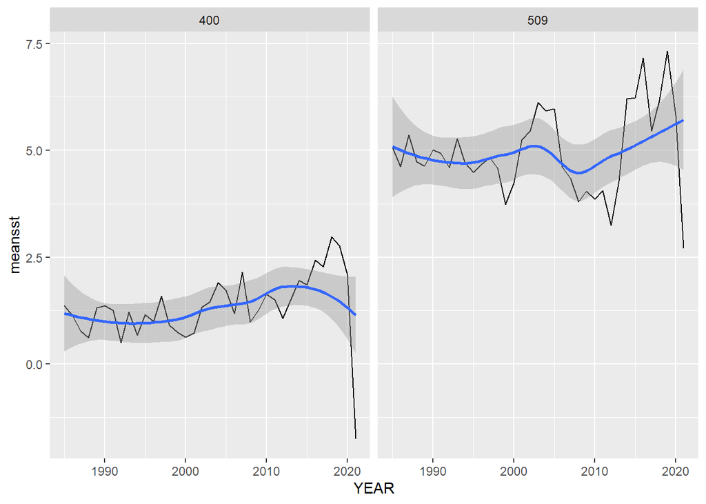

```r
httr::content(httr::GET('https://apex.psmfc.org/akfin/data_marts/akmp/nmfs_area_crw_avg_sst?nmfs_area=400,509&start_date=19850401&end_date=20220101'), type = "application/json") %>%
  bind_rows %>%
  mutate(date=as_date(READ_DATE),
         YEAR=as.numeric(YEAR)) %>%
  group_by(YEAR,NMFSAREA) %>%
  summarise(meansst=mean(MEANSST)) %>%
  ggplot(aes(YEAR,meansst)) +
  geom_line() +
  geom_smooth() +
  facet_wrap(~NMFSAREA)
```

References Skirving, W; Marsh, B; De La Cour, J; Liu, G; Harris, A; Maturi, E; Geiger, E; Eakin, CM. CoralTemp and the Coral Reef Watch Coral Bleaching Heat Stress Product Suite Version 3.1. Remote Sens. 2020, 12, 3856; https://doi.org/10.3390/rs12233856.